# Lecture 1.1:

What is Comparative Politics?

Emmanuel Teitelbaum

## Key Questions/Topics

- “How do states become powerful?”
- “Does ethnic diversity cause violent conflict?”
- “Why are women more politically powerful in some countries than others?”
- “Does greater civic participation lead to better democracy?”
- “Why are some countries rich and others poor?”

## Overview

- Theoretical perspectives
- Elements of an explanation
- Correlation versus causation

## Theoretical Perspectives

- Rational choice
- Cultural perspectives
- Structural perspectives

# Elements of an Explanation

- **Dependent variable**–Effect or outcome that we want to explain
- **Independent variable**–The factors that explain/cause the outcome

## Tree example

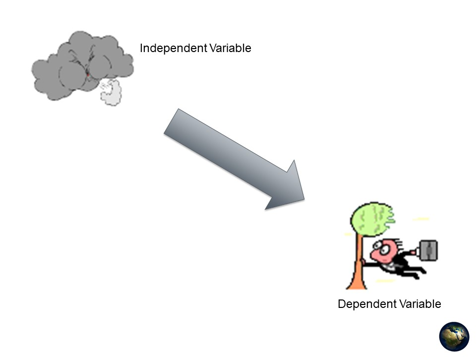

## Tree example

[figure not shown]

# Causal Mechanisms

- Set of intervening factors or variables (or ‘causal sequence’) that links a dependent and independent variable
- Story of the relationship between variables (the ‘because’)

## Democracy example

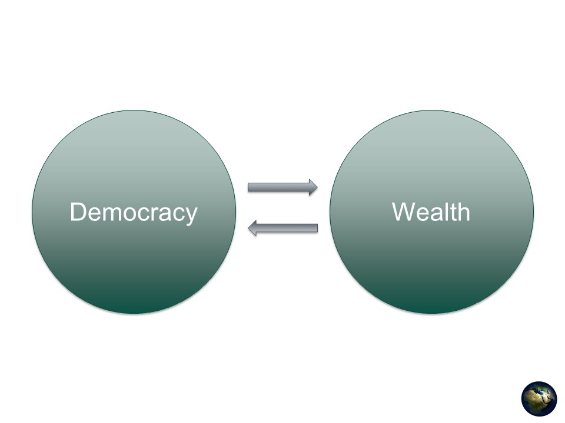

## Democracy example

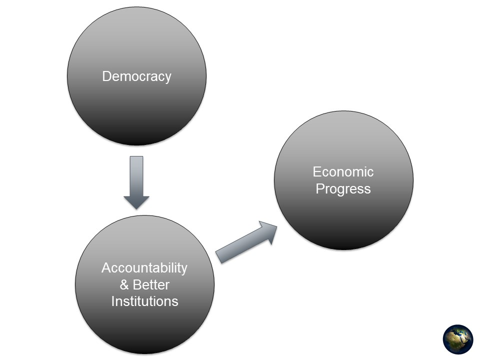

## Democracy example

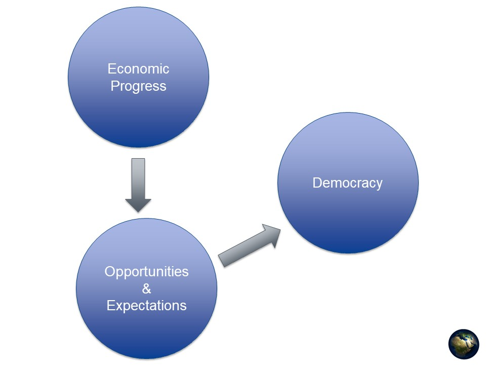

# Spurious Correlation

- Does correlation = causation?
- **Spurious correlation** occurs when two variables appear to be directly linked in a cause-effect relationship but in fact (a) there is no causal link whatsoever; or (b) they are linked indirectly by some other causal variable or variables
- Occurs when we cannot specify or demonstrate the mechanism

## Ice cream example

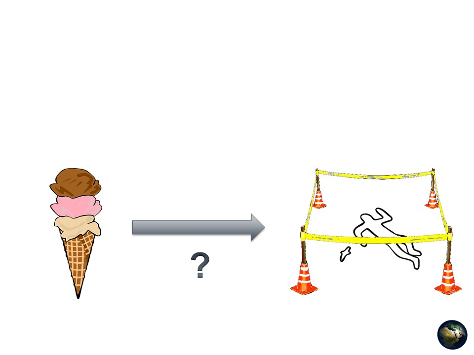

## Ice cream example

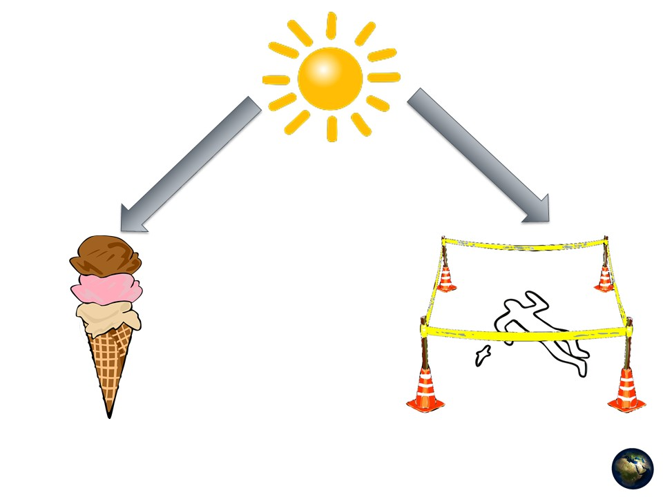

## R Code?

```r
summary(cars)
```

```
##      speed           dist
##  Min.   : 4.0   Min.   :  2.00
##  1st Qu.:12.0   1st Qu.: 26.00
##  Median :15.0   Median : 36.00
##  Mean   :15.4   Mean   : 42.98
##  3rd Qu.:19.0   3rd Qu.: 56.00
##  Max.   :25.0   Max.   :120.00
```